# Reproducible Research Assignment 1

## Imputing Data

```r
missingval <- sum(is.na(activity$steps))
missingval
```

```
## [1] 2304
```

2. Devise a strategy for filling in all of the missing values in the dataset. Create a new dataset that is equal to the original dataset but with the missing data filled in.

```r
activity.clean <- merge(activity, stepsPerday, by="date", suffixes=c("", ".mean"))
  nas <- is.na(activity.clean$steps)
  activity.clean$steps[nas] <- activity.clean$steps.mean[nas]
  activity.clean <- activity.clean[, c(1:3)]
  head(activity.clean)
```

```
##         date steps interval
## 1 2012-10-02     0     1740
## 2 2012-10-02     0     1715
## 3 2012-10-02     0     1725
## 4 2012-10-02     0     1710
## 5 2012-10-02     0     1735
## 6 2012-10-02     0     1855
```

```r
  summary(activity.clean)
```

```
##       date                steps           interval
##  Min.   :2012-10-02   Min.   :  0.00   Min.   :   0.0
##  1st Qu.:2012-10-16   1st Qu.:  0.00   1st Qu.: 588.8
##  Median :2012-10-29   Median :  0.00   Median :1177.5
##  Mean   :2012-10-30   Mean   : 37.38   Mean   :1177.5
##  3rd Qu.:2012-11-16   3rd Qu.: 12.00   3rd Qu.:1766.2
##  Max.   :2012-11-29   Max.   :806.00   Max.   :2355.0
```

```r
  stepsclean <- aggregate(steps ~ date, activity.clean, sum)
  stepsclean
```

```
##          date steps
## 1  2012-10-02   126
## 2  2012-10-03 11352
## 3  2012-10-04 12116
## 4  2012-10-05 13294
## 5  2012-10-06 15420
## 6  2012-10-07 11015
## 7  2012-10-09 12811
## 8  2012-10-10  9900
## 9  2012-10-11 10304
## 10 2012-10-12 17382
## 11 2012-10-13 12426
## 12 2012-10-14 15098
## 13 2012-10-15 10139
## 14 2012-10-16 15084
```

[output cut: 39 more lines]

3. Make a histogram of the total number of steps taken each day.

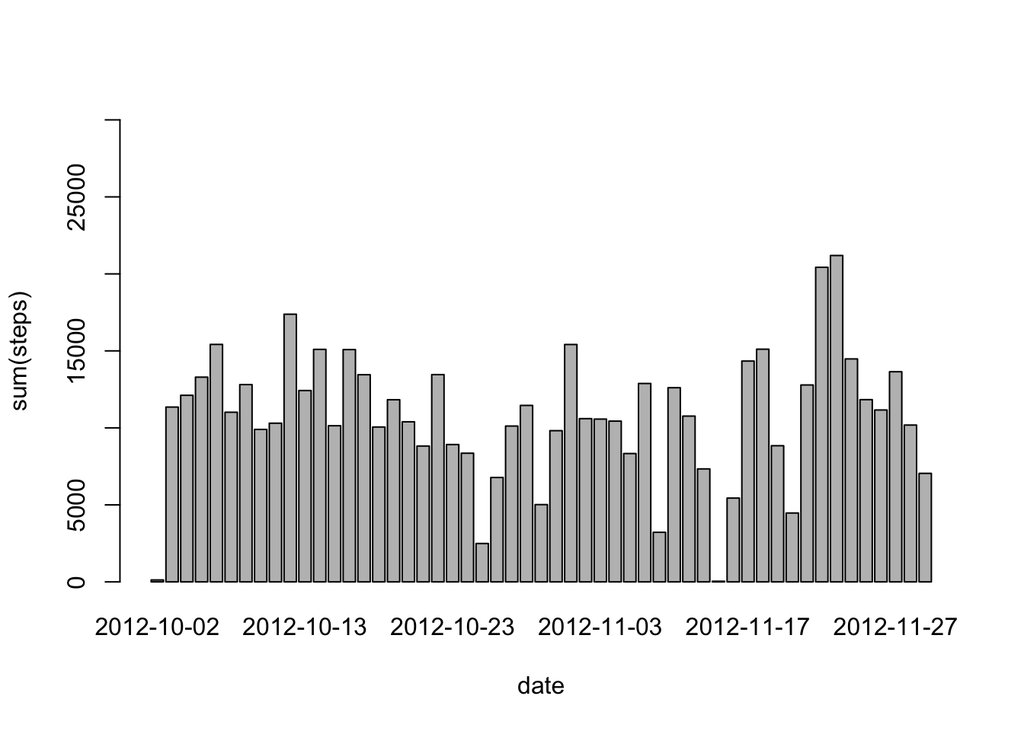

```r
stepsPerday <- aggregate(steps ~ date, activity.clean, sum)
barplot(stepsPerday$steps, names.arg=stepsPerday$date, ylim=c(0, 30000),
        xlab="date", ylab="sum(steps)",)
```

4. Calculate and report the mean and median total number of steps taken per day.

```r
mean(stepsPerday$steps)
```

```
## [1] 10766.19
```

```r
median(stepsPerday$steps)
```

```
## [1] 10765
```

## Are there differences in activity patterns between weekdays and weekends?

```
1   Create a new factor variable in the dataset with two levels – “weekday” and “weekend” indicating whether a given date is a weekday or weekend day.
```

```r
dayType <- function(dates) {
  f <- function(date) {
    if (weekdays(date) %in% c("Saturday", "Sunday")) {
      "weekend"
    }
    else {
      "weekday"
    }
  }
  sapply(dates, f)
}
activity$dayType <- as.factor(dayType(activity$date))
str(activity)
```

```
## 'data.frame':    17568 obs. of  4 variables:
##  $ steps   : int  NA NA NA NA NA NA NA NA NA NA ...
##  $ date    : Date, format: "2012-10-01" "2012-10-01" ...
##  $ interval: int  0 5 10 15 20 25 30 35 40 45 ...
##  $ dayType : Factor w/ 2 levels "weekday","weekend": 1 1 1 1 1 1 1 1 1 1 ...
```

2. Make a panel plot containing a time series plot (i.e. type =“l”) of the 5-minute interval (x-axis) and the average numbrer of steps taken, averaged across all weekday days or weekend days (y-axis).

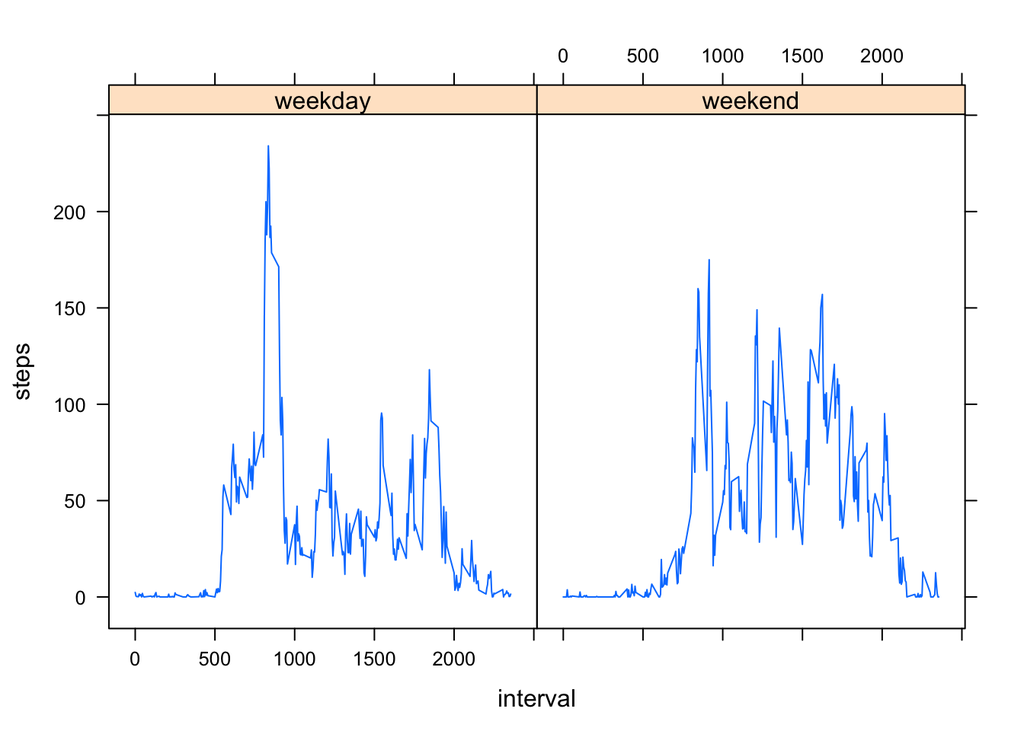

```r
library(lattice)

steps.interval <- aggregate(steps ~ interval + dayType, activity, mean)
xyplot(steps ~ interval | dayType, data=steps.interval, layout=c(2,1), type='l')
```